# Power Tests

Iliana Vasiliki Ntinou

5/28/2021

### Load libraries

```r
library(tidyverse)
library(lme4)
library(pwr)
```

### Run `biostats.apps::power_lm_app()` and explore the effect of the number of observations on the width of the confidence intervals, the proportion of trials that are statistically significant, and the effect size of significant trials.

```r
biostats.apps::power_lm_app()
```

Shiny applications not supported in static R Markdown documents

### Simulating a power test

A scientist is setting up an experiment to test whether a new type of food gives more weight gain in fish. They need to know how many fish they need to sample to have an 80% probability (i.e. power = 0.8) of getting a statistically significant result.

The experiment has a control (standard food) and a treatment arm (new food).

Fish typically have a mass of 1kg with a standard deviation of 0.2kg. The scientist hopes that the new food will give at least 0.1kg extra mass (otherwise it is not worth the extra cost).

```r
# data info
n <- 50 #number observations in each group
delta <- 0.1 #difference between means
sd <- 0.2 # standard deviation

# simulate means
mu <- rep(c(0, delta), each = n)

# add noise
y <- mu + rnorm(length(mu), sd = sd)

## predictor
x <- factor(rep(c("A", "B"), each = n))

# run test
test <- t.test(y ~ x)

test
```

```
##
##  Welch Two Sample t-test
##
## data:  y by x
## t = -1.9999, df = 97.005, p-value = 0.0483
## alternative hypothesis: true difference in means between group A and group B is not equal to 0
## 95 percent confidence interval:
##  -0.1600410936 -0.0006114299
## sample estimates:
## mean in group A mean in group B
##    -0.009935698     0.070390564
```

```r
broom::glance(test)
```

```
## # A tibble: 1 x 10
##   estimate estimate1 estimate2 statistic p.value parameter conf.low conf.high
##      <dbl>     <dbl>     <dbl>     <dbl>   <dbl>     <dbl>    <dbl>     <dbl>
## 1  -0.0803  -0.00994    0.0704     -2.00  0.0483      97.0   -0.160 -0.000611
## # ... with 2 more variables: method <chr>, alternative <chr>
```

*Make your simulation into a function and repeat it 100 times. What proportion of trials are statistically significant?*

```r
sim_t_test <- function(n, delta, sd, ...){

mu <- rep(c(0, delta), each = n) # simulate means

y <- mu + rnorm(length(mu), sd = sd) # add noise

x <- factor(rep(c("A", "B"), each = n)) # predictor

test <- t.test(y ~ x) # run test

broom::tidy(test) %>% mutate(n = n, delta = delta, sd = sd)
}

sim_t_test(n = 50, delta = 0.1, sd = 0.2)
```

```
## # A tibble: 1 x 13
##   estimate estimate1 estimate2 statistic p.value parameter conf.low conf.high
##      <dbl>     <dbl>     <dbl>     <dbl>   <dbl>     <dbl>    <dbl>     <dbl>
## 1   -0.151  -0.00274     0.148     -3.23 0.00166      98.0   -0.243   -0.0582
## # ... with 5 more variables: method <chr>, alternative <chr>, n <dbl>,
## #   delta <dbl>, sd <dbl>
```

```r
nrep = 100
control <- crossing(rep_no = 1:nrep, n = seq(10, 100, 20))

runs <- control %>% pmap_df(sim_t_test, delta = 0.1, sd = 0.2) %>% mutate(sig = p.value <= 0.05)
runs
```

```
## # A tibble: 500 x 14
##    estimate estimate1 estimate2 statistic   p.value parameter conf.low conf.high
##       <dbl>     <dbl>     <dbl>     <dbl>     <dbl>     <dbl>    <dbl>     <dbl>
##  1  -0.163    0.0150    0.178      -2.41  0.0275         16.8   -0.306  -0.0205
##  2  -0.140   -0.0205    0.119      -3.01  0.00382        57.8   -0.232  -0.0469
##  3  -0.147   -0.0564    0.0910     -3.62  0.000477       97.6   -0.228  -0.0665
##  4  -0.132   -0.00531   0.126      -3.94  0.000131      137.    -0.198  -0.0655
##  5  -0.0726   0.0153    0.0878     -2.18  0.0306        175.    -0.138  -0.00686
##  6  -0.0489  -0.0418    0.00705    -0.444 0.663          17.0   -0.281   0.184
##  7  -0.0932   0.00207   0.0953     -1.73  0.0881         57.8   -0.201   0.0143
##  8  -0.0451   0.0217    0.0669     -1.10  0.273          98.0   -0.126   0.0361
##  9  -0.136   -0.0409    0.0948     -4.01  0.0000989     136.    -0.203  -0.0688
## 10  -0.123   -0.00810   0.115      -4.04  0.0000787     178.    -0.183  -0.0629
## # ... with 490 more rows, and 6 more variables: method <chr>,
## #   alternative <chr>, n <dbl>, delta <dbl>, sd <dbl>, sig <lgl>
```

```r
# see the proportion of trials that are significant
(sum ( runs$sig == TRUE )) / 500
```

```
## [1] 0.614
```

*Plot your results.*

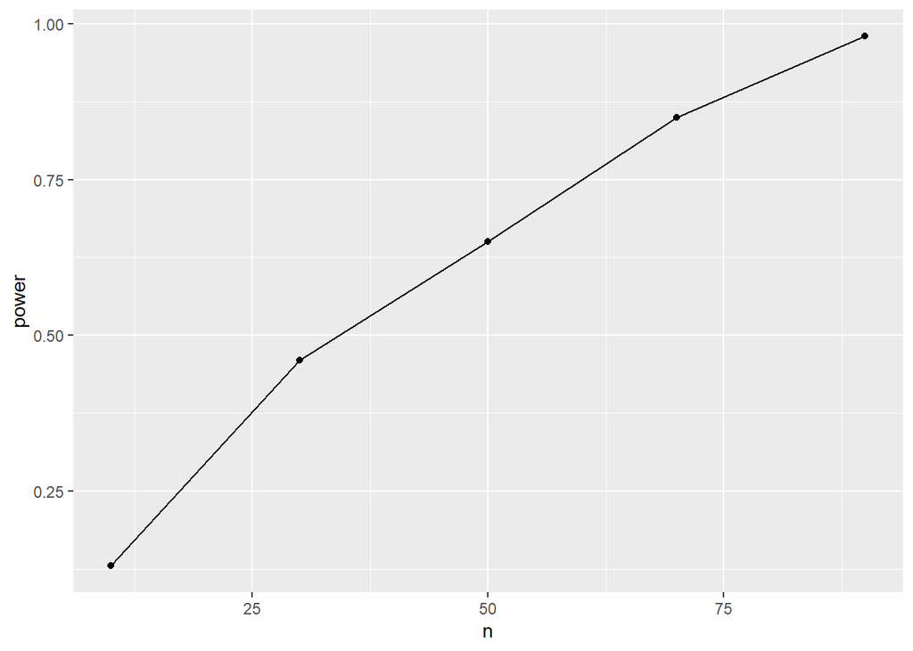

```r
p <- runs  %>%
  group_by(n) %>%
  summarise(power = mean(sig)) %>%
  ggplot(aes(x = n, y = power)) +
  geom_line() +
  geom_point()
p
```

*Run the simulation for different numbers of fish. How many are needed to get enough power?*

### A second variable

The scientist thinks that a second variable, temperature, is also important, so expands the experiment to include this second variable with two levels, cool and warm.

*Extend your power analysis to cope with the new experimental design.*

*How many fish do they need to get enough power.*

### Distribution of p values under Null hypothesis

*Simulate some data where the null hypothesis is true (ie effect size is zero).*

*Compare this to the distribution of p-values calculated above.*